# Анализ мощности

## Линейные модели, осень 2014

Марина Варфоломеева  
Каф. Зоологии беспозвоночных, СПбГУ

## Экономим силы с помощью анализа мощности

- Статистические ошибки при проверке гипотез
- Мощность статистического теста
- *A priori* анализ мощности, оценка величины эффекта
- *Post hoc* анализ мощности
- Как влиять на мощность тестов

### Вы сможете

- дать определение ошибок I и II рода, мощности теста, и изобразить их вероятности на графике
- оценивать величину эффекта и необходимый объем выборки по данным пилотного исследования (a priori анализ мощности)
- загружать данные из .csv в R
- строить боксплоты с помощью `ggplot2`, раскрашивать их, менять темы оформления
- сравнивать средние значения при помощи t-критерия, интерпретировать и описывать результаты
- расчитывать фактическую мощность теста (post hoc анализ мощности)

# Статистические ошибки при проверке гипотез

## Типы ошибок при проверке гипотез

|  | H0 == TRUE | H0 == FALSE |
| --- | --- | --- |
| Отклонить H0 | **Ошибка I рода** Ложно-положительный результат | Верно Положительный результат |
| Сохранить H0 | Верно Отрицательный результат | **Ошибка II рода** Ложно-отрицательный результат |

### Вероятности гипотез

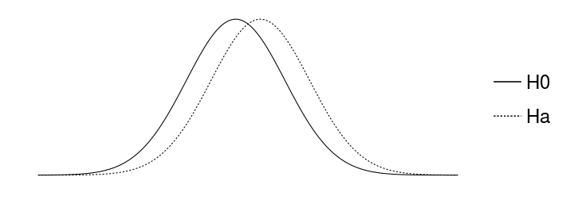

## Типы ошибок при проверке гипотез

|  | H0 == TRUE | H0 == FALSE |
| --- | --- | --- |
| Отклонить H0 | **Ошибка I рода** Ложно-положительный результат | Верно Положительный результат |
| Сохранить H0 | Верно Отрицательный результат | **Ошибка II рода** Ложно-отрицательный результат |

### Ошибки I рода

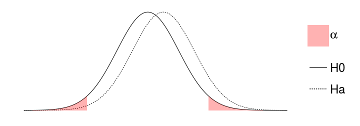

## Типы ошибок при проверке гипотез

|  | H0 == TRUE | H0 == FALSE |
| --- | --- | --- |
| Отклонить H0 | **Ошибка I рода** Ложно-положительный результат | Верно Положительный результат |
| Сохранить H0 | Верно Отрицательный результат | **Ошибка II рода** Ложно-отрицательный результат |

### Ошибки II рода

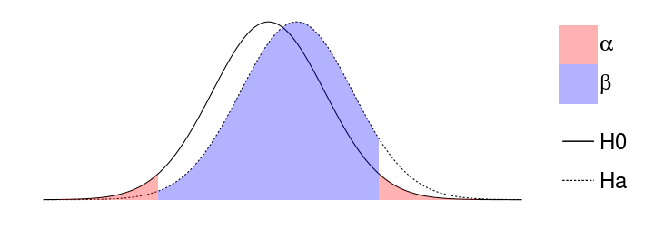

## Типы ошибок при проверке гипотез

|  | H0 == TRUE | H0 == FALSE |
| --- | --- | --- |
| Отклонить H0 | **Ошибка I рода** Ложно-положительный результат | Верно Положительный результат |
| Сохранить H0 | Верно Отрицательный результат | **Ошибка II рода** Ложно-отрицательный результат |

### Мощность теста - способность выявлять различия \(Power = 1 - \beta\)

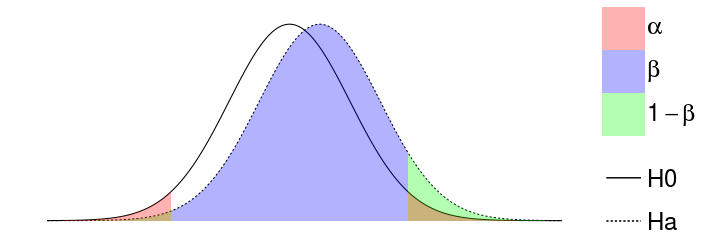

## Анализ мощности

*A priori*

- какой нужен объем выборки, чтобы найти различия с разумной долей уверенности?
- различия какой величины мы можем найти, если известен объем выборки?

*Post hoc*

- смогли бы мы найти различия при помощи нашего эксперимента (\(\alpha\), \(n\)), если бы величина эффекта была \(X\)?

# A priory анализ мощности

## Пример: Заповедник спасает халиотисов *

Лов халиотисов (коммерческий и любительский) запретили, организовав заповедник.

Стало ли больше моллюсков через несколько лет? (Keough, King, 1991)

### Для a priori анализа нужно знать

- тест - \(t\)-критерий
- уровень значимости - \(alpha = 0.05\)
- желаемая мощность теста - 80%
- ожидаемая величина эффекта - ?

* - Данные из Quinn, Keough, 2002, Box 9-5, Fig 9-7

## Как оценить ожидаемую величину эффекта?

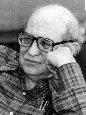

Яков Коэн

\(d\) Коэна (Cohen's d)

\[d = \frac{\bar \mu_1 - \bar \mu_2}{\sigma}\]

- Пилотные исследования
- Литература
- Общебиологические знания
- Технические требования

### Как оценить стандартное отклонение для расчета величины эффекта?

- как среднеквадратичное стандартное отклонение  
  (\(d\) Коэна)

\[d = \frac{|\bar x_1 - \bar x_2|} {\sqrt{\frac {s_1^2 + s_2^2 } {2} }}\]

- как обобщенное стандартное отклонение  
  (\(g\) Хеджа)

\[g = \frac{|\bar x _1 - \bar x _2|} {\sqrt{\frac {(n _1 - 1)s_1^2 + (n _2 - 1)s_2^2 } {n _1 + n _2 - 2} } }\]

## Величина эффекта из общих соображений

Яков Коэн (1982)

сильные, умеренные и слабые эффекты

```r
library(pwr)
cohen.ES(test = "t", size = "large")
```

```
#
#      Conventional effect size from Cohen (1982)
#
#            test = t
#            size = large
#     effect.size = 0.8
```

## Величина эффекта из пилотных данных

\[d = \frac{\bar \mu_1 - \bar \mu_2}{\sigma}\]

### \({\sigma}\) - cтандартное отклонение плотности халиотисов:

- Плотность крупных халиотисов на \(50 м^2\) была \(\bar x = 47.5\), \(SD = 27.7\)

### \({\bar \mu_1 - \bar \mu_2}\) - cредний вылов халиотисов в год:

- Масса выловленных коммерческим способом + данные о размерах -> численность -> плотность -> коммерческий лов = 11.6 экз. \(м^{-2}\)
- -> общий вылов = 23.2 экз. \(м^{-2}\) (если любительский и коммерческий лов равны)

## Величина эффекта из пилотных данных

\[d = \frac{\bar \mu_1 - \bar \mu_2}{\sigma}\]

### \({\sigma}\) - cтандартное отклонение плотности халиотисов:

- Плотность крупных халиотисов на \(50 м^2\) была \(\bar x = 47.5\), \(SD = 27.7\)

### \({\bar \mu_1 - \bar \mu_2}\) - cредний вылов халиотисов в год:

- Масса выловленных коммерческим способом + данные о размерах -> численность -> плотность -> коммерческий лов = 11.6 экз. \(м^{-2}\)
- -> общий вылов = 23.2 экз. \(м^{-2}\) (если любительский и коммерческий лов равны)

```r
alpha <- 0.05
power <- 0.80
sigma <- 27.7 # варьирование плотности халиотисов
diff <- 23.2 # ожидаемые различия плотности халиотисов
(effect <- diff/sigma) # величина эффекта
```

```
# [1] 0.838
```

## Считаем объем выборки

### Функции для анализа мощности t-критерия

- при одинаковых объемах групп `pwr.t.test()`
- при разных объемах групп `pwr.t2n.test()`

```r
pwr.t.test(n = NULL, d = effect, power = power, sig.level = alpha,
           type = "two.sample", alternative = "two.sided")
```

```
#
#      Two-sample t test power calculation
#
#               n = 23.4
#               d = 0.838
#       sig.level = 0.05
#           power = 0.8
#     alternative = two.sided
#
# NOTE: n is number in *each* group
```

- Чтобы с вероятностью 0.8 выявить различия плотности халиотисов в местах, где лов разрешен и запрещен, нужно обследовать **по 24 места каждого типа**, если мы верно оценили величину эффекта.

## Решение

```r
cohen.ES(test = "t", size = "small")
```

```
#
#      Conventional effect size from Cohen (1982)
#
#            test = t
#            size = small
#     effect.size = 0.2
```

```r
pwr.t.test(n = NULL, d = 0.2, power = 0.8, sig.level = 0.01,
           type = "two.sample", alternative = "two.sided")
```

```
#
#      Two-sample t test power calculation
#
#               n = 586
#               d = 0.2
#       sig.level = 0.01
#           power = 0.8
#     alternative = two.sided
#
# NOTE: n is number in *each* group
```

## Пример: Улитки*

Улитки *Patelloida mimula* на устрицах *Saccostrea glomerata*? Minchinton, Ross, 1999

Сколько нужно проб, чтобы показать, что плотность улиток различается между сайтами?

* - Данные из Quinn, Keough, 2002, Box 9-5, Fig 9-7.

### Читаем данные из файла

Не забудте войти в вашу директорию для матметодов

Читаем из `.csv`

```r
minch <- read.table("./data/minch.csv",
                    header = TRUE, sep = "\t")
```

Или читаем из `.xls`

```r
library(XLConnect)
minch <- readWorksheetFromFile("./data/minch.xls",
                               sheet = 1)
```

- Кто помнит, как посмотреть, что внутри переменной `minch`?

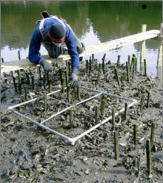

Фото: http://users.monash.edu.au/~murray/stats/BIO4200/Eworksheets/images/oysters.jpg

## Просмотреть, что внутри переменной `minch` можно так:

```r
# Структура данных
str(minch)
# Первые несколько строк
head(minch, 2)
# Первые три значения переменной zone
minch$zone[1:3]
# 2-3 строки и 3, 5, 7 столбцы
minch[2:3, c(1, 3, 5)]
# Полностью столбцы site и zone
minch[, c("site", "zone")]
```

## Боксплот числа улиток в двух сайтах

Геом `geom_boxplot`

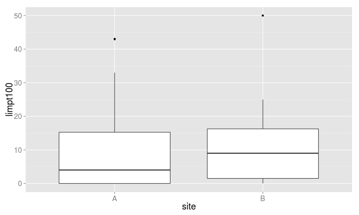

```r
library(ggplot2)
gglimp <- ggplot(data = minch, aes(x = site, y = limpt100))
gglimp + geom_boxplot()
```

## Раскрашиваем график

эстетика `fill`

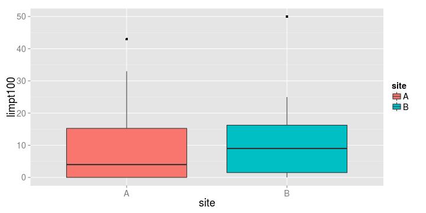

```r
gglimp + geom_boxplot(aes(fill = site))
```

## Решение:

```
gglimp + geom_boxplot(aes(colour = site))
gglimp + geom_boxplot(aes(fill = zone))
gglimp + geom_boxplot(aes(colour = zone))
```

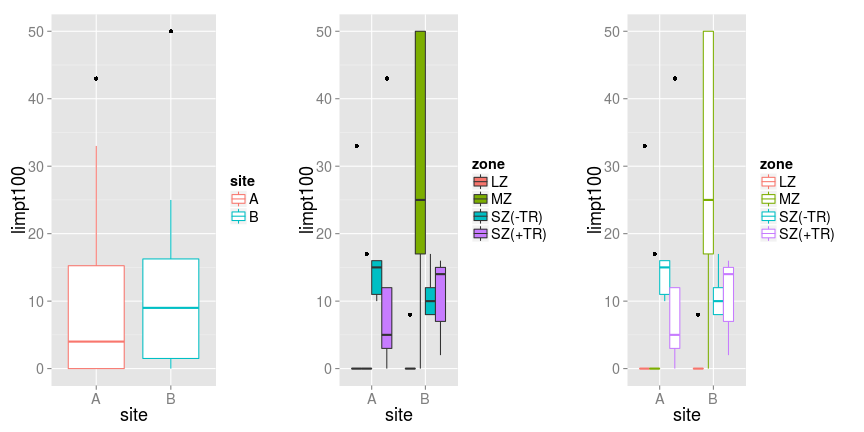

## Не нравится тема? Можно привинтить другую!

Можно прибавить к графику `theme_bw()`, `theme_classic()`, `theme_grey()`, `theme_minimal()`, `theme_light()`

```r
gglimp + geom_boxplot(aes(fill = site)) + theme_classic()
```

Можно установить для всех последующих графиков `theme_set()`

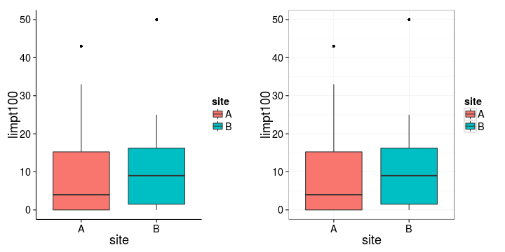

```r
theme_set(theme_bw()) # тема до конца сеанса
gglimp + geom_boxplot(aes(fill = site))
```

# A priory анализ мощности по данным пилотного исследования

## Пилотное исследование

Какой объем выборки нужен, чтобы доказать что численность улиток различается между сайтами?

### Величина эффекта по исходным данным

```r
library(effsize)
effect <- cohen.d(minch$limpt100, minch$site)
effect
```

```
#
# Cohen's d
#
# d estimate: -0.293 (small)
# 95 percent confidence interval:
#    inf    sup
# -0.953  0.368
```

- как добыть из переменной effect значение величины эффекта?

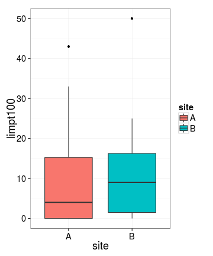

## Обращении к переменным по имени - `$`

### Как называется в структуре объекта элемент, где записана величина эффекта?

```r
str(effect) # effect$estimate
```

```
# List of 7
#  $ method    : chr "Cohen's d"
#  $ name      : chr "d"
#  $ estimate  : Named num -0.293
#   ..- attr(*, "names")= chr "A"
#  $ conf.int  : Named num [1:2] -0.953 0.368
#   ..- attr(*, "names")= chr [1:2] "inf" "sup"
#  $ var       : Named num 0.326
#   ..- attr(*, "names")= chr "A"
#  $ conf.level: num 0.95
#  $ magnitude : chr "small"
#  - attr(*, "class")= chr "effsize"
```

```r
# Для pwr.t.test() эффект должен быть положительным, поэтому вычислим модуль
effect <- abs(effect$estimate)
```

## Решение

```r
pwr.t.test(n = NULL, d = effect, power = 0.8, sig.level = 0.05,
           type = "two.sample", alternative = "two.sided")
```

```
#
#      Two-sample t test power calculation
#
#               n = 184
#               d = 0.293
#       sig.level = 0.05
#           power = 0.8
#     alternative = two.sided
#
# NOTE: n is number in *each* group
```

- Площадок должно быть **185 с каждого сайта**, чтобы с вероятностью 0.8 обнаружить различия плотности улиток между сайтами.

# Post hoc анализ мощности

## На самом деле различия действительно не были найдены

* - Данные из Quinn, Keough, 2002, Box 7-1, Fig 7-4

```r
t.test(limpt100 ~ site, data = minch,
       var.equal = FALSE)
```

```
#
#   Welch Two Sample t-test
#
# data:  limpt100 by site
# t = -0.926, df = 36.7, p-value = 0.3605
# alternative hypothesis: true difference in means is not equal to 0
# 95 percent confidence interval:
#  -12.44   4.64
# sample estimates:
# mean in group A mean in group B
#            9.05           12.95
```

- Достоверных различий плотности улиток между локациями не обнаружено (t-критерий)

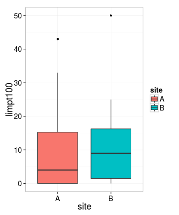

## Post hoc анализ - когда различий не нашли

Какова была реальная величина эффекта?

Хватило ли нам мощности, чтобы выявлять такие незначительные различия?

### Для post hoc анализа нужно знать

```r
effect_real <- cohen.d(minch$limpt100, minch$site)
effect_real <- abs(effect_real$estimate)
pwr.t.test(n = 20, d = effect_real,
           power = NULL, sig.level = 0.05,
           type = "two.sample",
           alternative = "two.sided")
```

```
#
#      Two-sample t test power calculation
#
#               n = 20
#               d = 0.293
#       sig.level = 0.05
#           power = 0.147
#     alternative = two.sided
#
# NOTE: n is number in *each* group
```

# Как влиять на мощность теста?

## Чем больше объем выборки—тем больше мощность

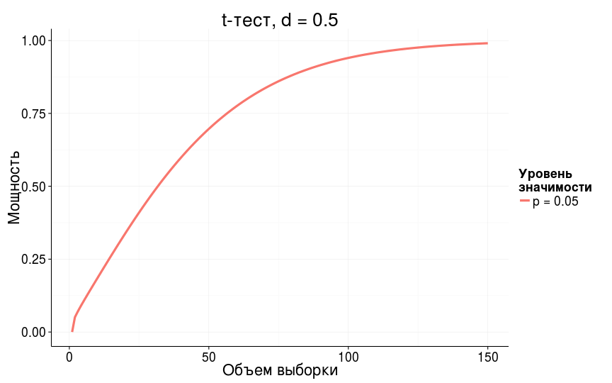

## Чем больше уровень значимости—тем больше мощность

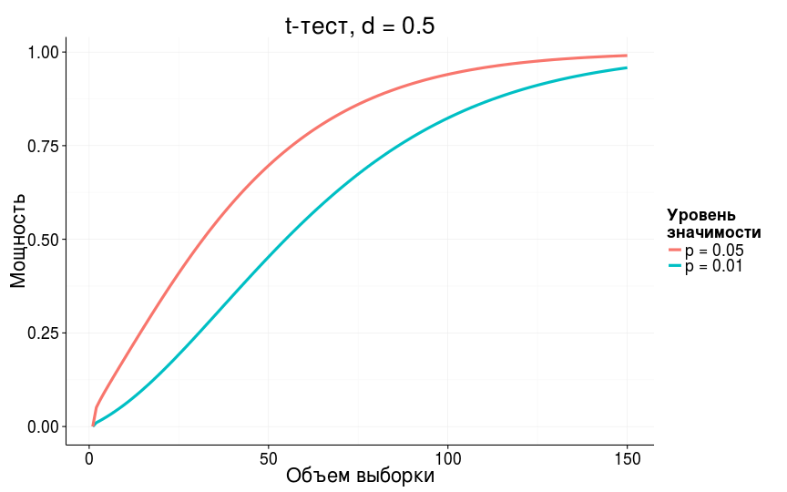

## Чем больше величина различий—тем больше мощность

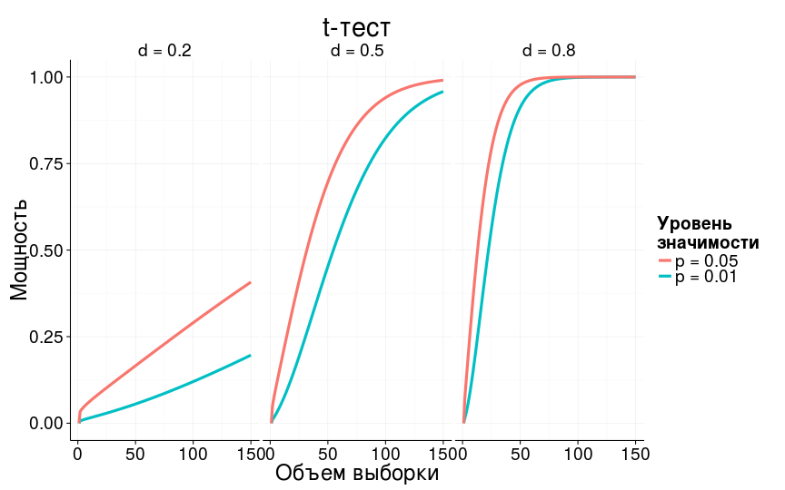

## Take home messages

- Контролируем статистические ошибки:
  - чтобы не находить несуществующих эффектов, фиксируем уровень значимости
  - чтобы не пропустить значимое, рассчитываем величину эффекта, объем выборки и мощность теста
  - когда не обнаружили достоверных эффектов, оцениваем величину эффекта и мощность теста
- Способность выявлять различия зависит
  - от объема выборки,
  - от уровня значимости
  - от величины эффекта

# Дополнительные ресурсы

- Quinn, Keough, 2002, pp. 164-170
- Open Intro to Statistics: [4.6 Sample Size and Power](http://www.openintro.org/stat/down/oiStat2_04.pdf), pp. 193-197
- Sokal, Rohlf, 1995, pp. 167-169.
- Zar, 1999, p. 83.
- [R Data Analysis Examples - Power Analysis for Two-group Independent sample t-test. UCLA: Statistical Consulting Group.](http://www.ats.ucla.edu/stat/r/dae/t_test_power2.htm)
- [R Data Analysis Examples - Power Analysis for One-sample t-test. UCLA: Statistical Consulting Group.](http://www.ats.ucla.edu/stat/r/dae/t_test_power.htm)
- [FAQ - How is effect size used in power analysis? UCLA: Statistical Consulting Group.](http://www.ats.ucla.edu/stat/mult_pkg/faq/general/effect_size_power/effect_size_power.htm)